# Plot Kansas School District Cash Balances – Summary

Earl F Glynn

2022-10-03

# 1 Setup

## 1.1

## 1.2 Constants

```r
FILE_PREFIX   <- "x"    # no spaces
```

```r
EXCEL_LIMIT <- 2^20
```

## 1.3 Packages

```r
library(tidyverse)
```

Display formatting

```r
library(kableExtra)  # kable_styling
```

```r
#library(IRdisplay)   # display_html (needed in Jupyter notebooks)
```

I/O

```r
library(readxl)      # read_xlsx
library(readr)       # write_csv
library(writexl)     # write_xlsx
```

Graphics

```r
library(scales)      # comma, comma_format
```

```r
library(lubridate)
```

## 1.4 ggplot theme

[ggplot Themes Gallery](https://www.datanovia.com/en/blog/ggplot-themes-gallery/)

```r
theme_set(theme_minimal() +

          theme(axis.text             = element_text(size = 10),
                axis.title            = element_text(size = 14),

                plot.caption          = element_text(hjust = c(0.0,1.0)),
                plot.caption.position = "plot",   # R 4.0.0

                plot.title.position   = "plot",
                plot.title            = element_text(size = 13),
                plot.subtitle         = element_text(size = 11))
           )
```

```r
COLOR_BAR     <- "skyblue"
COLOR_OUTLINE <- "grey80"
```

## 1.5 Helper functions

```r
Show <- function(data, caption="", bigMark="",
                 height = NULL, width = NULL, ...)
{
  data                                       %>%
  kable("html", caption=caption,
        format.args=list(big.mark=bigMark))  %>%
  kable_styling(bootstrap_options=c("striped", "bordered", "condensed"),
                position="left",
                full_width=FALSE, ...)       %>%
  scroll_box(height = height, width = width)#%>%      # pixels
# as.character()                             %>%      # Jupyter Only
# display_html()                                      # Jupyter Only
}
```

# 2 Total Cash Balances from All School Districts

```r
SOURCE <- "Source:  Kansas Department of Education, School Finance Reports"
stamp  <- paste("watchdoglab.substack.com  efg", format(Sys.time(), "%Y-%m-%d"))
```

## 2.1 Read summary data

```r
yearSummaryWide <- read_xlsx("Cash-Balance-Totals-and-Quantiles-by-School-Year-WideFormat.xlsx")
dim(yearSummaryWide)
```

```
[1] 15 11
```

By school year this table shows:

- Number of school districts
- Sum of Cash Balance for all districts
- Quantiles of Cash Balances by school district
- Q0 = 0th percentile (smallest school district cash balance)
- Q0.1 = 10th percentile
- Q0.25 = 25th percentile
- Q0.5 = 50th percentile (median school district cash balance)
- Q0.75 = 75th percentile
- Q0.9 = 90th percentile
- Q1 = 100th percentile (largest school district cash balance)

```r
yearSummaryWide %>% Show(bigMark = ",")
```

| SchoolYear | n | nDistrict | CashSum | CashQ0 | CashQ0.1 | CashQ0.25 | CashQ0.5 | CashQ0.75 | CashQ0.9 | CashQ1 |
| --- | --- | --- | --- | --- | --- | --- | --- | --- | --- | --- |
| 2007-2008 | 295 | 295 | 1,233,499,737 | 52,725 | 515,685.2 | 847,654 | 1,448,033 | 2,785,958 | 6,755,982 | 117,473,404 |
| 2008-2009 | 293 | 293 | 1,365,519,937 | 136,968 | 514,439.0 | 891,487 | 1,560,030 | 2,865,292 | 7,453,351 | 135,888,224 |
| 2009-2010 | 289 | 289 | 1,507,651,564 | 83,230 | 621,286.0 | 1,128,958 | 1,871,285 | 3,251,271 | 9,020,193 | 158,986,189 |
| 2010-2011 | 286 | 286 | 1,578,483,017 | -16,107,103 | 754,144.5 | 1,274,742 | 2,024,222 | 4,013,695 | 9,514,118 | 172,337,822 |
| 2011-2012 | 286 | 286 | 1,724,719,345 | 265,181 | 808,859.5 | 1,383,557 | 2,215,281 | 4,330,702 | 10,320,385 | 155,688,042 |
| 2012-2013 | 286 | 286 | 1,715,088,748 | 396,815 | 837,783.5 | 1,385,596 | 2,208,634 | 4,347,092 | 10,936,297 | 151,092,914 |
| 2013-2014 | 286 | 286 | 1,700,098,353 | -10,663,094 | 828,431.0 | 1,332,162 | 2,096,481 | 4,294,059 | 10,892,061 | 163,873,541 |
| 2014-2015 | 286 | 286 | 1,709,990,591 | 134,825 | 776,918.5 | 1,238,826 | 2,116,322 | 4,185,375 | 11,369,554 | 151,335,277 |
| 2015-2016 | 286 | 286 | 1,741,637,176 | 237,454 | 748,406.0 | 1,262,399 | 2,158,683 | 4,289,302 | 11,467,874 | 142,339,010 |
| 2016-2017 | 286 | 286 | 1,872,858,628 | 310,977 | 806,804.0 | 1,334,277 | 2,306,664 | 4,768,456 | 12,013,767 | 160,436,118 |
| 2017-2018 | 286 | 286 | 2,020,556,670 | 349,395 | 813,410.0 | 1,425,446 | 2,445,543 | 4,985,715 | 13,608,019 | 168,311,080 |
| 2018-2019 | 286 | 286 | 2,111,370,884 | 261,561 | 896,124.5 | 1,497,528 | 2,457,082 | 5,070,017 | 13,606,302 | 174,708,566 |
| 2019-2020 | 286 | 286 | 2,180,300,077 | 161,446 | 875,110.5 | 1,507,646 | 2,518,653 | 4,627,572 | 14,255,339 | 188,409,060 |
| 2020-2021 | 286 | 286 | 2,275,165,148 | 196,788 | 898,990.5 | 1,476,421 | 2,658,139 | 5,359,008 | 14,831,646 | 212,198,590 |
| 2021-2022 | 286 | 286 | 2,360,697,508 | 202,451 | 840,633.0 | 1,619,714 | 2,821,675 | 5,709,113 | 16,206,439 | 230,946,953 |

## 2.2 Add dates for plots

The `Cash Balances` School Finance Report gives this data description:

```
Cash Balances for each fund as of July 1 and broken down by district with state totals.

*Cash balances may vary due to timing of the report or possible changes on the CPA audit that are not reflected in the USD budget data*
```

```r
yearSummary <-
  yearSummaryWide   %>%
  select(SchoolYear, CashSum)  %>%
  mutate(
          MidYear   = ymd( paste0( str_sub(SchoolYear, 6, 9), "-01-01"))
        )           %>%
  relocate(MidYear)
```

```r
yearSummary %>%  Show(bigMark = ",")
```

| MidYear | SchoolYear | CashSum |
| --- | --- | --- |
| 2008-01-01 | 2007-2008 | 1,233,499,737 |
| 2009-01-01 | 2008-2009 | 1,365,519,937 |
| 2010-01-01 | 2009-2010 | 1,507,651,564 |
| 2011-01-01 | 2010-2011 | 1,578,483,017 |
| 2012-01-01 | 2011-2012 | 1,724,719,345 |
| 2013-01-01 | 2012-2013 | 1,715,088,748 |
| 2014-01-01 | 2013-2014 | 1,700,098,353 |
| 2015-01-01 | 2014-2015 | 1,709,990,591 |
| 2016-01-01 | 2015-2016 | 1,741,637,176 |
| 2017-01-01 | 2016-2017 | 1,872,858,628 |
| 2018-01-01 | 2017-2018 | 2,020,556,670 |
| 2019-01-01 | 2018-2019 | 2,111,370,884 |
| 2020-01-01 | 2019-2020 | 2,180,300,077 |
| 2021-01-01 | 2020-2021 | 2,275,165,148 |
| 2022-01-01 | 2021-2022 | 2,360,697,508 |

## 2.3 Barplot by school year

```r
governor <-
  tibble(
          Name = c("Sebelius", "Parkinson", "Brownback",
                   "Colyer", "Kelly"),

          TermStart = ymd("2007-07-01",  # for plotting purposes
                          "2009-04-28", "2011-01-10",
                          "2018-01-31", "2019-01-14"),

          TermEnd   = ymd("2009-04-28", "2011-01-10", "2018-01-31",
                          "2019-01-14",
                          "2022-12-31"),   # for plotting purposes,

          fraction1  = c(1.00, 0.93, 1.00, 0.93, 1.00),
          fraction2  = c(1.00, 0.60, 1.00, 0.60, 1.00),

          color     = c("D", "D", "R", "R", "D"),

          Q = rep(1, 5)  # Kludge for 2nd plot
        )
```

```r
governor %>% Show()
```

| Name | TermStart | TermEnd | fraction1 | fraction2 | color | Q |
| --- | --- | --- | --- | --- | --- | --- |
| Sebelius | 2007-07-01 | 2009-04-28 | 1.00 | 1.0 | D | 1 |
| Parkinson | 2009-04-28 | 2011-01-10 | 0.93 | 0.6 | D | 1 |
| Brownback | 2011-01-10 | 2018-01-31 | 1.00 | 1.0 | R | 1 |
| Colyer | 2018-01-31 | 2019-01-14 | 0.93 | 0.6 | R | 1 |
| Kelly | 2019-01-14 | 2022-12-31 | 1.00 | 1.0 | D | 1 |

```r
Brownback <- governor %>% filter(Name == "Brownback")
```

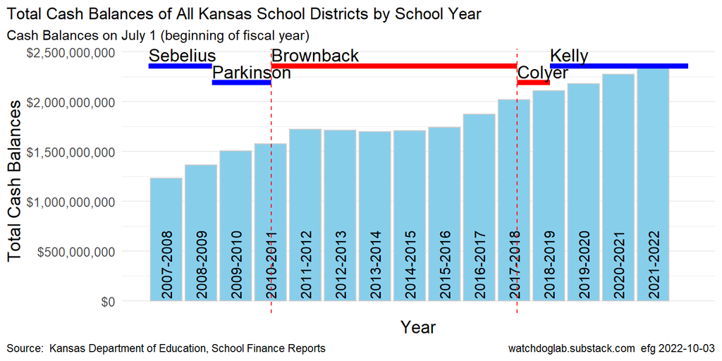

```r
ggplot(data = yearSummary) +
  geom_col(aes(x = MidYear, y = CashSum),
           fill = "skyblue", colour = "grey80") +
  labs(title    = paste("Total Cash Balances of All Kansas School Districts",
                        "by School Year"),
       subtitle = "Cash Balances on July 1 (beginning of fiscal year)",
       x = "Year",
       y = "Total Cash Balances",
       caption = c(SOURCE, stamp))              +
  scale_y_continuous(labels = scales::dollar)   +
  theme(axis.text.x = element_blank(),
        panel.grid.major.x = element_blank(),
        panel.grid.minor.x = element_blank(),
        legend.position = "none")               +
  geom_text(data = yearSummary,
            aes(x = MidYear, y = 20E6,
                label = SchoolYear),
                vjust = 0.5, hjust = 0, size = 4, angle = 90)  +
  geom_segment(data = governor,
               aes(x = TermStart,  y    =  fraction1 * max(yearSummary$CashSum),
               xend = TermEnd,     yend =  fraction1 * max(yearSummary$CashSum),
               linetype = "solid",
               color = color), size = 2)           +
  geom_text(data = governor,
            aes(x = TermStart, y =  1.02 * fraction1 * max(yearSummary$CashSum),
                label = Name),
                vjust = 0.0, hjust = 0, size = 5)  +
  scale_color_manual(values = c("D" = "blue", "R" = "red"))  +
  geom_vline(xintercept = c(Brownback$TermStart, Brownback$TermEnd),
             color = "red", linetype = "dashed")
```

Notes:

- Total Cash Balances were the sums of Cash Balances of all Unified School Districts in Kansas.
- There were 295 school districts in 2007-2008, 293 in 2008-2009, and 286 from 2010-2011 till present.
- Values of yearly July 1 Cash Balances by school district, as well as totals of all districts, can be viewed in file Cash-Balances-by-School-District-WideFormat-Edited.xlsx.

# 3 Variability of Cash Balance Across Kansas School Districts

```r
yearSummaryLong <-
    read_xlsx("Cash-Balance-Totals-and-Quantiles-by-School-Year-LongFormat.xlsx") %>%
    select(-n, -nDistrict)  %>%
    mutate(
            StartYear   = ymd( paste0( str_sub(SchoolYear, 1, 4), "-07-01"))
          )           %>%
  relocate(StartYear)

dim(yearSummaryLong)
```

```
[1] 105   5
```

```r
yearSummaryLong  %>%  head(7)  %>%  Show(bigMark = ",")
```

| StartYear | SchoolYear | CashSum | qValue | Q |
| --- | --- | --- | --- | --- |
| 2007-07-01 | 2007-2008 | 1,233,499,737 | 52,725.0 | 0.00 |
| 2007-07-01 | 2007-2008 | 1,233,499,737 | 515,685.2 | 0.10 |
| 2007-07-01 | 2007-2008 | 1,233,499,737 | 847,654.0 | 0.25 |
| 2007-07-01 | 2007-2008 | 1,233,499,737 | 1,448,033.0 | 0.50 |
| 2007-07-01 | 2007-2008 | 1,233,499,737 | 2,785,958.0 | 0.75 |
| 2007-07-01 | 2007-2008 | 1,233,499,737 | 6,755,981.6 | 0.90 |
| 2007-07-01 | 2007-2008 | 1,233,499,737 | 117,473,404.0 | 1.00 |

```r
labels =
  tibble(Q     = c(0, 0.1, 0.25, 0.5, 0.75, 0.9, 1),
         label = c("Smallest", "10th percentile", "25th percentile",
                   "Median", "75th percentle", "90th percentle",
                   "Largest"))


lastPoints <-
  yearSummaryLong                    %>%
  filter(SchoolYear == "2021-2022")  %>%
  inner_join(labels, by = "Q")

dim(lastPoints)
```

```
[1] 7 6
```

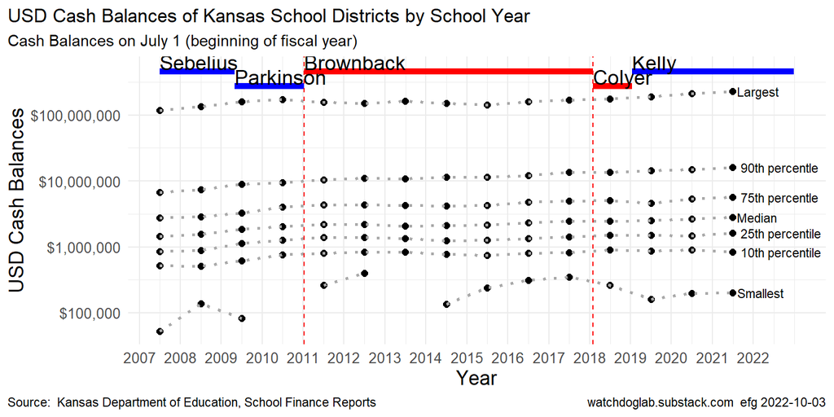

```r
ggplot(yearSummaryLong, aes(x = StartYear, y = qValue, group = Q)) +
  geom_point(size = 2, color = "black")             +
  geom_line(size = 1, color = "darkgrey", linetype = "dotted")   +
  scale_y_log10(breaks = 10^(4:8),
                labels = scales::label_dollar())    +
  scale_x_date(breaks = ymd(paste0(2007:2022, "-01-01")),
               date_labels = "%Y")   +
  labs(title    = paste("USD Cash Balances of Kansas School Districts",
                        "by School Year"),
       subtitle = "Cash Balances on July 1 (beginning of fiscal year)",
       x = "Year",
       y = "USD Cash Balances",
       caption = c(SOURCE, stamp))    +
  theme(legend.position = "none")    +
  geom_segment(data = governor,
               aes(x = TermStart,  y    =  2 * fraction2 * max(yearSummaryLong$qValue),
               xend = TermEnd,     yend =  2 * fraction2 * max(yearSummaryLong$qValue),
               linetype = "solid",
               color = color), size = 2)      +
  geom_text(data = governor,
            aes(x = TermStart, y =  2.1 * fraction2 * max(yearSummaryLong$qValue),
                label = Name),
                vjust = 0.0, hjust = 0, size = 5)  +
  scale_color_manual(values = c("D" = "blue", "R" = "red")) +
  geom_vline(xintercept = c(Brownback$TermStart, Brownback$TermEnd),
             color = "red", linetype = "dashed")   +
  geom_text(data = lastPoints, label = lastPoints$label,
            adj = -0.1, color = "black", size = 3)
```

Notes:

- The “smallest” values were negative in 2010-2011 and 2013-2014 and cannot be included as part of a log scale..
- In 2010-2011 **USD 473, Chapman (Dickinson County)**, showed a deficit of $18,473,393 on 7/1/2010 for Capital Outlay (fund 16), and a Total USD Cash Balance deficit of $16,107,103. See files Cash-Balances-2010-2011.xls and 2010-2011-Cash-Balance.xls.
- In 2013-2014 **USD 475, Geary County Schools**, showed a deficit of 33,976,147 on 7/1/2013 for Federal (fund 07), and a Total USD Cash Balance deficit of $10,663,094. See files Cash-Balances-2013-2014.xls and 2013-2014-Cash-Balance.xls.
- Quantile values (0.0, 0.1, 0.25, 0.5, 0.75, 0.9, 1.0) by School Year can be found in file Cash-Balance-Totals-and-Quantiles-by-School-Year-WideFormat.xlsx.

# 4 Epilog

## 4.1

Processing time: 1.9 secs

2022-10-03 0147